# Regressão Linear

# Pré-processamento

Para executar nosso primeiro exemplo de regressão linear, iremos utilizar a base de dados [characters_GOT](https://github.com/claudioalvesmonteiro/nice-data-repo/blob/master/data/characters_GOT.csv) da série Game of Thrones, onde consta todos os personages e algumas informações ligadas a cada um. Como variável dependente temos o número de mortes relacionadas ao personagem `numdeadrelations` e como variáveis independentes temos: `male`; `house`; `ismarried`; `isnoble`; e `popularity`.

```r
library(readr)
GOTdata <- read_csv("dados/characters_GOT.csv")
```

Agora vamos criar um objeto dataframe com apenas as variaveis que queremos em nossa análise.

```r
GOTanalysis <- GOTdata[,c("numdeadrelations", "male", "house", "ismarried", "isnoble", "popularity")]
```

Observe a variável `house`. Temos um problema de missing cases, que neste caso significa que o personagem não pertence a nenhuma “casa” (família). Também há outro problema que é o grande número de casas, o que torna inviável colocar essa variável diretamente no modelo. Quais opções de tranformação/recodificação você daria como solução para esse caso?

```r
# definir NAs como "sem casa"
GOTanalysis$house[is.na(GOTanalysis$house)] <- "Without House/Unknow"

# criar variaveis a partir das casas
library(dplyr)
GOTanalysis <- mutate(GOTanalysis, house_tyrell = ifelse(house == "House Tyrell", 1, 0))
GOTanalysis <- mutate(GOTanalysis, house_targaryen = ifelse(house == "House Targaryen", 1, 0))
GOTanalysis <- mutate(GOTanalysis, house_lannister = ifelse(house == "House Lannister", 1, 0))
```

# Modelo de Regressão Linear

```r
# executar modelo
modelo1 <- lm(numdeadrelations ~ # VD
                male +           # VIs
                house_tyrell +
                house_targaryen +
                house_lannister +
                ismarried +
                isnoble +
                popularity,
              data = GOTanalysis)

# visualizar resultados
summary(modelo1)
```

```
##
## Call:
## lm(formula = numdeadrelations ~ male + house_tyrell + house_targaryen +
##     house_lannister + ismarried + isnoble + popularity, data = GOTanalysis)
##
## Residuals:
##     Min      1Q  Median      3Q     Max
## -4.9056 -0.1764  0.0477  0.1414 11.7157
##
## Coefficients:
##                 Estimate Std. Error t value Pr(>|t|)
## (Intercept)     -0.11702    0.04426  -2.644  0.00827 **
## maleTRUE        -0.09794    0.05110  -1.917  0.05541 .
## house_tyrell    -0.56091    0.17946  -3.125  0.00180 **
## house_targaryen  1.39166    0.13939   9.984  < 2e-16 ***
## house_lannister  0.38359    0.15470   2.480  0.01324 *
## ismarriedTRUE    0.02107    0.07367   0.286  0.77494
## isnobleTRUE     -0.05901    0.04992  -1.182  0.23731
## popularity       5.17958    0.15996  32.380  < 2e-16 ***
## ---
## Signif. codes:  0 '***' 0.001 '**' 0.01 '*' 0.05 '.' 0.1 ' ' 1
##
## Residual standard error: 1.06 on 1938 degrees of freedom
## Multiple R-squared:  0.416,  Adjusted R-squared:  0.4139
## F-statistic: 197.2 on 7 and 1938 DF,  p-value: < 2.2e-16
```

```r
# visualizar resultados com stargazer
library(stargazer)
stargazer(modelo1, type = "text", title = "Model Results", style = "ajps", p.auto = FALSE)
```

```
##
## Model Results
## ---------------------------------------------
##                         numdeadrelations
## ---------------------------------------------
## male                         -0.098*
##                              (0.051)
## house_tyrell                -0.561***
##                              (0.179)
## house_targaryen             1.392***
##                              (0.139)
## house_lannister              0.384**
##                              (0.155)
## ismarried                     0.021
##                              (0.074)
## isnoble                      -0.059
##                              (0.050)
## popularity                  5.180***
##                              (0.160)
## Constant                    -0.117***
##                              (0.044)
## N                             1946
## R-squared                     0.416
## Adj. R-squared                0.414
## Residual Std. Error     1.060 (df = 1938)
## F Statistic         197.188*** (df = 7; 1938)
## ---------------------------------------------
## ***p < .01; **p < .05; *p < .1
```

# Visualização de Dados em Modelos de Regressão

## Gráfico de Dispersão

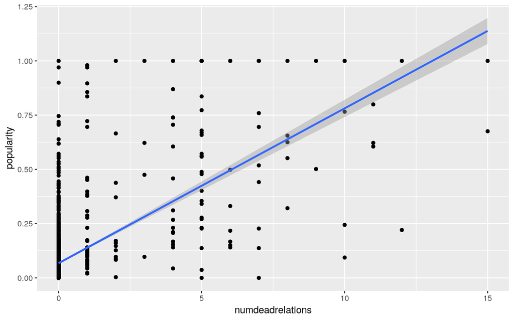

```r
# grafico de dispersao + reta de estimativa do modelo
library(ggplot2)
ggplot(data = GOTanalysis, aes(x = numdeadrelations, y = popularity))+
  geom_point()+
  geom_smooth(method = "lm")
```

## Homocedasticidade

```r
# salvando valores preditos e residuos para analise de homocedasticidade
GOTanalysis$Predito <- predict(modelo1)
GOTanalysis$Residuo <- GOTanalysis$numdeadrelations - GOTanalysis$Predito

# Testar se a media do erro e igual a 0
summary(GOTanalysis$Residuo)
```

```
##     Min.  1st Qu.   Median     Mean  3rd Qu.     Max.
## -4.90562 -0.17643  0.04772  0.00000  0.14138 11.71571
```

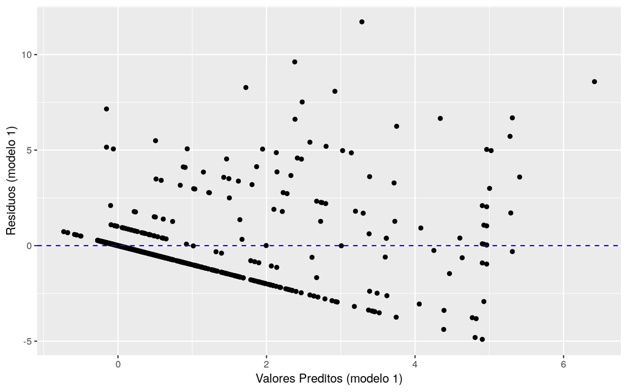

```r
# grafico de dispersao dos valores preditos x residuos
ggplot(data = GOTanalysis, aes(x = Predito, y=Residuo)) +
  geom_point() +
  labs( x ="Valores Preditos (modelo 1)", y = "Residuos (modelo 1)") +
  geom_hline(yintercept = 0, linetype = "dashed", color = "blue")
```

# Exercicios

Para praticar, baixe o banco de dados [QOGdataSave.csv](https://github.com/claudioalvesmonteiro/nice-data-repo/blob/master/data/epi2018countrysnapshotv01.csv) e analise o efeito da corrupção (political_corruption) e das exportações (total_export) sobre o EPI (environmental_performance_index). Faça um modelo de regressão linear com essas variáveis, apresente gráficos de dispersão entre a VD e cada VI e por fim o gráfico de homocedasticidade. Atente-se às informações presentes nas variáveis, talvez seja necessário algum tipo de pré-processamento.

Analytique Consultoria

Janeiro, 2018